# Assignment Re-test (Intro to R)

Abhishek Bhatia

26th September 2019

1. Use the “AirPassengers” dataset for the following

```r
# It's a time series object
class(AirPassengers)
```

```
## [1] "ts"
```

```r
ts.obj <- AirPassengers
# Extract year for each observation
year <- floor(time(AirPassengers))
year
```

```
##       Jan  Feb  Mar  Apr  May  Jun  Jul  Aug  Sep  Oct  Nov  Dec
## 1949 1949 1949 1949 1949 1949 1949 1949 1949 1949 1949 1949 1949
## 1950 1950 1950 1950 1950 1950 1950 1950 1950 1950 1950 1950 1950
## 1951 1951 1951 1951 1951 1951 1951 1951 1951 1951 1951 1951 1951
## 1952 1952 1952 1952 1952 1952 1952 1952 1952 1952 1952 1952 1952
## 1953 1953 1953 1953 1953 1953 1953 1953 1953 1953 1953 1953 1953
## 1954 1954 1954 1954 1954 1954 1954 1954 1954 1954 1954 1954 1954
## 1955 1955 1955 1955 1955 1955 1955 1955 1955 1955 1955 1955 1955
## 1956 1956 1956 1956 1956 1956 1956 1956 1956 1956 1956 1956 1956
## 1957 1957 1957 1957 1957 1957 1957 1957 1957 1957 1957 1957 1957
## 1958 1958 1958 1958 1958 1958 1958 1958 1958 1958 1958 1958 1958
## 1959 1959 1959 1959 1959 1959 1959 1959 1959 1959 1959 1959 1959
## 1960 1960 1960 1960 1960 1960 1960 1960 1960 1960 1960 1960 1960
```

```r
# Since it's a time series object it has a cycle
# We need to extract the sampling times at each observation i.e. Months
month <- month.abb[cycle(ts.obj)]
month
```

```
##   [1] "Jan" "Feb" "Mar" "Apr" "May" "Jun" "Jul" "Aug" "Sep" "Oct" "Nov"
##  [12] "Dec" "Jan" "Feb" "Mar" "Apr" "May" "Jun" "Jul" "Aug" "Sep" "Oct"
##  [23] "Nov" "Dec" "Jan" "Feb" "Mar" "Apr" "May" "Jun" "Jul" "Aug" "Sep"
##  [34] "Oct" "Nov" "Dec" "Jan" "Feb" "Mar" "Apr" "May" "Jun" "Jul" "Aug"
##  [45] "Sep" "Oct" "Nov" "Dec" "Jan" "Feb" "Mar" "Apr" "May" "Jun" "Jul"
##  [56] "Aug" "Sep" "Oct" "Nov" "Dec" "Jan" "Feb" "Mar" "Apr" "May" "Jun"
##  [67] "Jul" "Aug" "Sep" "Oct" "Nov" "Dec" "Jan" "Feb" "Mar" "Apr" "May"
##  [78] "Jun" "Jul" "Aug" "Sep" "Oct" "Nov" "Dec" "Jan" "Feb" "Mar" "Apr"
##  [89] "May" "Jun" "Jul" "Aug" "Sep" "Oct" "Nov" "Dec" "Jan" "Feb" "Mar"
## [100] "Apr" "May" "Jun" "Jul" "Aug" "Sep" "Oct" "Nov" "Dec" "Jan" "Feb"
## [111] "Mar" "Apr" "May" "Jun" "Jul" "Aug" "Sep" "Oct" "Nov" "Dec" "Jan"
## [122] "Feb" "Mar" "Apr" "May" "Jun" "Jul" "Aug" "Sep" "Oct" "Nov" "Dec"
## [133] "Jan" "Feb" "Mar" "Apr" "May" "Jun" "Jul" "Aug" "Sep" "Oct" "Nov"
## [144] "Dec"
```

```r
# Finally we can create the dataframe
# Now our data is in tidy format (one row for each observation)
df <- data.frame(AirPassengers=as.matrix(ts.obj), year=year, month=month)
head(df)
```

```
##   AirPassengers year month
## 1           112 1949   Jan
## 2           118 1949   Feb
## 3           132 1949   Mar
## 4           129 1949   Apr
## 5           121 1949   May
## 6           135 1949   Jun
```

1. Create dataframe with month name for the dataset as below:

```r
df2 <- df[, -which(colnames(df) == "year")]
head(df2)
```

```
##   AirPassengers month
## 1           112   Jan
## 2           118   Feb
## 3           132   Mar
## 4           129   Apr
## 5           121   May
## 6           135   Jun
```

2. Find the monthly average passengers for each months

```r
df.monmean <-
  aggregate(df[, -which(colnames(df) %in% c("year", "month"))],
            by=list(df$month), mean, na.rm = T)

colnames(df.monmean) <- c("month", "Mean.AirPassengers")
# The months are ordered alphabetically
df.monmean
```

```
##    month Mean.AirPassengers
## 1    Apr           267.0833
## 2    Aug           351.0833
## 3    Dec           261.8333
## 4    Feb           235.0000
## 5    Jan           241.7500
## 6    Jul           351.3333
## 7    Jun           311.6667
## 8    Mar           270.1667
## 9    May           271.8333
## 10   Nov           232.8333
## 11   Oct           266.5833
## 12   Sep           302.4167
```

```r
# Convert month column into ordered factor vector
# with order corresponding to the actual month timing
# Create a function to sort a df by month
sort.monthly <- function(df, month.col){
  df[, month.col] <- factor(df[, month.col], levels = month.abb, ordered = T)
  df <- df[order(df[, month.col]), ]
  return(df)

}
# Present the results in month time-sorted order
sort.monthly(df.monmean, "month")
```

```
##    month Mean.AirPassengers
## 5    Jan           241.7500
## 4    Feb           235.0000
## 8    Mar           270.1667
## 1    Apr           267.0833
## 9    May           271.8333
## 7    Jun           311.6667
## 6    Jul           351.3333
## 2    Aug           351.0833
## 12   Sep           302.4167
## 11   Oct           266.5833
## 10   Nov           232.8333
## 3    Dec           261.8333
```

3. Plot the monthly variance for each month

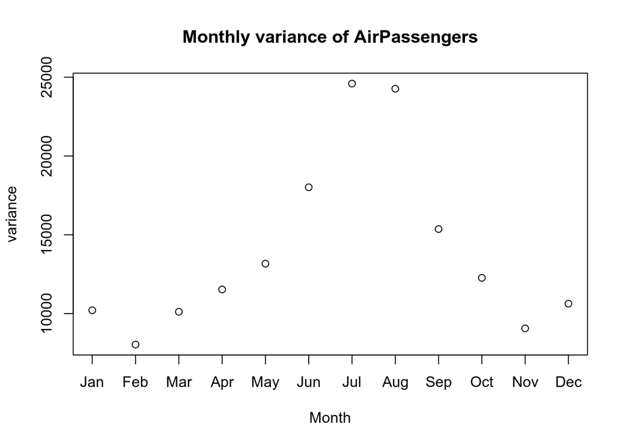

```r
df.monvar <- aggregate(df$AirPassengers, by=list(df$month), var, na.rm = T)
colnames(df.monvar) <- c("month", "Variance.AirPassengers")
# Present the results in month time-sorted order
df.monvar <- sort.monthly(df.monvar, "month")

plot(df.monvar$Variance.AirPassengers, pch=1, xaxt="n", xlab="Month",
     ylab="variance", main="Monthly variance of AirPassengers")

axis(1, at=1:12, labels=df.monvar$month)
```

2. Create a vector having the following elements  
   2, 3, -4, 5, 9, 1, -3, 2

```r
v <- c(2, 3, -4, 5, 9, 1, -3, 2)
```

Compute log 2 of all the elements of vec1

```r
log2.v <- log2(v)
log2.v
```

```
## [1] 1.000000 1.584963      NaN 2.321928 3.169925 0.000000      NaN 1.000000
```

```r
log2.v.nan.ind <- is.nan(log2.v)
```

Plot the result in y-axis and element values in the x-axis as point plot. The NaN produced should be replaced with 0 and appear as red in the plot.

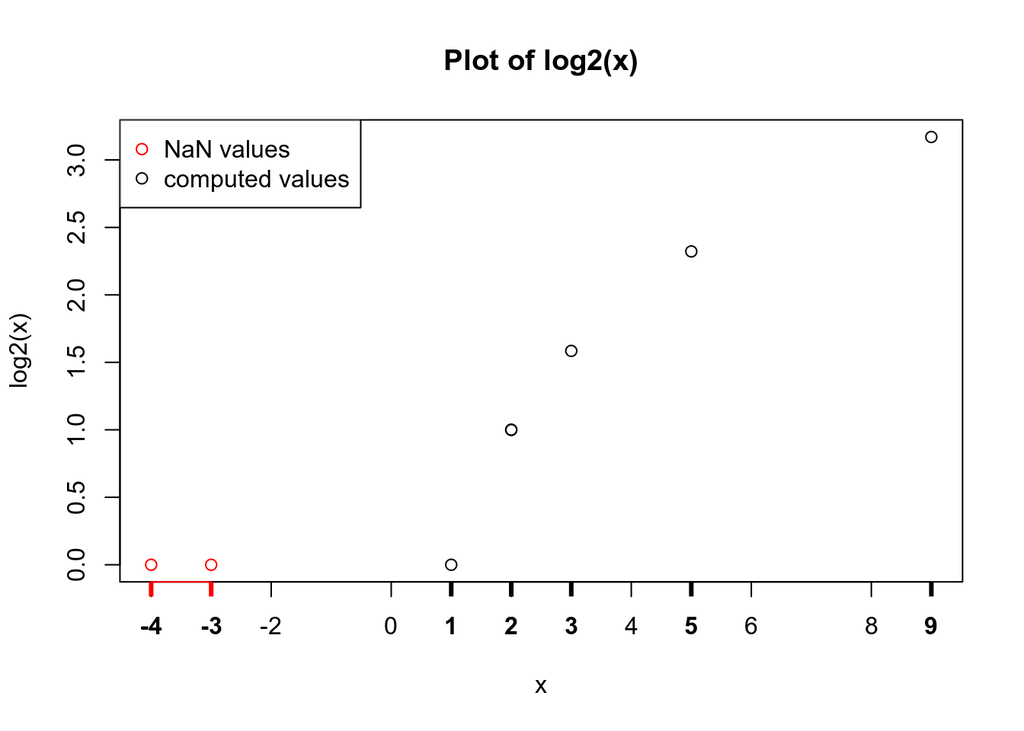

```r
cols <- rep("black", times = length(v))
# red color where log2 of the vector is NaN
cols[log2.v.nan.ind] <- "red"
# Finally replace NaN with 0
log2.v[log2.v.nan.ind] <- 0
# plot!
plot(v, log2.v, col = cols,
     main="Plot of log2(x)",
     xlab="x",
     ylab="log2(x)")

# Add tickmarks corresponding to values in the vector
axis(1, at = v[!log2.v.nan.ind], lend=1, font=2, lwd.ticks = 3, col = "black")
axis(1, at = v[log2.v.nan.ind], lend=1, font=2, lwd.ticks = 3, col = "red")

legend("topleft",
       c("NaN values", "computed values"),
       col=c("red", "black"),
       pch = 1
)
```

Import the dataset datafile.csv and find the following

```r
f <- "data/datafile.csv"
# Check what kind of file we have by reading in first 3 lines
for (l in readLines(f, 3)){
  cat(l, "\n")
}
```

```
## "household","age_husband","age_wife","income_husband","income_wife","bedrooms","electricity","gas","number_children","internet","mode","own","language","decade_built"
## 48,64,62,11000,29200,1,90,3,0,"Yes","followup","Owned with mortgage or loan","English only",1940
## 218,63,64,100000,3100,4,230,30,0,"Yes","mail","Owned with mortgage or loan","English only",1990
```

```r
# The file seems to be comma separated, so we can use sep = "," or read.csv
df <- read.csv(f)
head(df)
```

```
##   household age_husband age_wife income_husband income_wife bedrooms
## 1        48          64       62          11000       29200        1
## 2       218          63       64         100000        3100        4
## 3       279          56       51          31000           0        2
## 4       612          71       68          51700        8800        3
## 5       947          37       33          16600       26000        3
## 6      1373          86       91          77500       30000        4
##   electricity gas number_children internet     mode
## 1          90   3               0      Yes followup
## 2         230  30               0      Yes     mail
## 3         200  40               0       No followup
## 4         170   3               0      Yes internet
## 5         260   3               2      Yes internet
## 6          20  30               0      Yes internet
##                           own     language decade_built
## 1 Owned with mortgage or loan English only         1940
## 2 Owned with mortgage or loan English only         1990
## 3                      Rented English only         1950
## 4        Owned free and clear English only         1950
## 5 Owned with mortgage or loan English only         1990
## 6        Owned free and clear English only         1980
```

1. How many entries are present where husband’s age is less than wife’s age?

```r
sum(df$age_husband < df$age_wife)
```

```
## [1] 1684
```

Compute the total income as addition of husband’s income and wife’s income to find the households having total income more than 500000. Code should return corresponding household number.

```r
row.names(
  subset(df, (income_husband + income_wife) > 500000)
)
```

```
##  [1] "64"   "225"  "258"  "517"  "569"  "610"  "1078" "1236" "1370" "1535"
## [11] "2092" "2156" "2176" "2409" "3095" "3179" "3437" "3538" "3561" "3633"
## [21] "3684" "3821" "4379" "4442" "4526" "4545" "4618" "4620" "5209" "5518"
## [31] "6153" "6281" "6349" "6413" "6665" "6847" "7220" "7226" "7549" "7724"
```

Create an additional column with the criterion as “Status” having values as  
Both husband and wife age more than 65: “Level 1”  
Husband greater than 65 but wife less than 65: “Level 2”  
Both Less than 65 but greater than equal to 55: “Level 3”  
Both less than 50: “Level 4”

```r
status <- rep(NA_character_, length=nrow(df))
cond.lst <- list()

cond.lst[["hus.wf.gt65"]] <- which((df$age_husband > 65 &(df$age_wife > 65)))
cond.lst[["hus.gt65.wf.lt65"]] <- which((df$age_husband > 65 & (df$age_wife < 65)))
cond.lst[["hus.wf.lt65.ge55"]] <- which(
  (df$age_husband < 65 & df$age_husband >= 55)
  &
    (df$age_wife < 65 & df$age_wife >= 55)
  )
cond.lst[["hus.wf.lt50"]] <- which(
  (df$age_husband < 50)
  &
    (df$age_wife < 50)
)

# Now we have the indices of the rows corresponding to the conditions
# stored in a list
str(cond.lst)
```

```
## List of 4
##  $ hus.wf.gt65     : int [1:1449] 4 6 7 8 12 15 25 35 39 41 ...
##  $ hus.gt65.wf.lt65: int [1:408] 50 119 184 199 202 243 259 307 312 314 ...
##  $ hus.wf.lt65.ge55: int [1:1232] 1 2 14 16 19 21 34 42 52 67 ...
##  $ hus.wf.lt50     : int [1:2910] 5 9 10 11 18 20 23 24 26 28 ...
```

```r
# Store the status names (levels) according to the condition
status.levels <- list(
  hus.wf.gt65="Level 1",
  hus.gt65.wf.lt65="Level 2",
  hus.wf.lt65.ge55="Level 3",
  hus.wf.lt50="Level 4"
)

# Assign values to status vector
for (n in names(status.levels)){
  ind <- cond.lst[[n]]
  level.name <- status.levels[[n]]
  status[ind] <- level.name
}

df[, "Status"] <- status
head(df)
```

```
##   household age_husband age_wife income_husband income_wife bedrooms
## 1        48          64       62          11000       29200        1
## 2       218          63       64         100000        3100        4
## 3       279          56       51          31000           0        2
## 4       612          71       68          51700        8800        3
## 5       947          37       33          16600       26000        3
## 6      1373          86       91          77500       30000        4
##   electricity gas number_children internet     mode
## 1          90   3               0      Yes followup
## 2         230  30               0      Yes     mail
## 3         200  40               0       No followup
## 4         170   3               0      Yes internet
## 5         260   3               2      Yes internet
## 6          20  30               0      Yes internet
##                           own     language decade_built  Status
## 1 Owned with mortgage or loan English only         1940 Level 3
## 2 Owned with mortgage or loan English only         1990 Level 3
## 3                      Rented English only         1950    <NA>
## 4        Owned free and clear English only         1950 Level 1
## 5 Owned with mortgage or loan English only         1990 Level 4
## 6        Owned free and clear English only         1980 Level 1
```

Also find how many household are there in each of the levels such that to create an external file (.csv)

```r
status.df <- data.frame(t(table(df$Status)))
status.df
```

```
##   Var1    Var2 Freq
## 1    A Level 1 1449
## 2    A Level 2  408
## 3    A Level 3 1232
## 4    A Level 4 2910
```

```r
# Remove Var1 column
status.df <- status.df[, -which(colnames(status.df) == "Var1")]
colnames(status.df) <- c("Status", "Number of Households")
status.df
```

```
##    Status Number of Households
## 1 Level 1                 1449
## 2 Level 2                  408
## 3 Level 3                 1232
## 4 Level 4                 2910
```

```r
# Write the file
ofile <- "output/Household_status.csv"
write.csv(status.df, ofile, row.names = F)
```